# Introduction to Data Analysis

Author

Jamal Rogers

## 1. Introduction

Data Analysis involves exploring and interpreting datasets to uncover patterns, trends, and relationships that inform decisions. Some advanced statistical analysis and machine learning techniques rely on basic data analysis. In this lesson, we will still use polars and plotnine.

**Setup**

```python
# Install if not yet installed
# !pip install polars plotnine

import polars as pl
import pandas as pd
from plotnine import ggplot, aes, geom_point, geom_smooth, geom_bar, labs, theme_minimal
```

## 2. Loading and Inspecting Data

We’ll use the diamonds dataset as an example.

```python
# Load sample diamonds dataset
diamonds = pl.read_csv("https://raw.githubusercontent.com/mwaskom/seaborn-data/master/diamonds.csv")

# Display first few rows
diamonds.head()
```

shape: (5, 10)

| carat f64 | cut str | color str | clarity str | depth f64 | table f64 | price i64 | x f64 | y f64 | z f64 |
| --- | --- | --- | --- | --- | --- | --- | --- | --- | --- |
| 0.23 | "Ideal" | "E" | "SI2" | 61.5 | 55.0 | 326 | 3.95 | 3.98 | 2.43 |
| 0.21 | "Premium" | "E" | "SI1" | 59.8 | 61.0 | 326 | 3.89 | 3.84 | 2.31 |
| 0.23 | "Good" | "E" | "VS1" | 56.9 | 65.0 | 327 | 4.05 | 4.07 | 2.31 |
| 0.29 | "Premium" | "I" | "VS2" | 62.4 | 58.0 | 334 | 4.2 | 4.23 | 2.63 |
| 0.31 | "Good" | "J" | "SI2" | 63.3 | 58.0 | 335 | 4.34 | 4.35 | 2.75 |

Each row represents a diamonds with attributes like carat, cut, color, clarity, and price. The goal is to find patterns that explain how attributes relate to price.

## 3. Finding Patterns in Data

Let’s begin by summarizing and visualizing.

**Summary Statistics**

```python
diamonds.describe()
```

shape: (9, 11)

| statistic str | carat f64 | cut str | color str | clarity str | depth f64 | table f64 | price f64 | x f64 | y f64 | z f64 |
| --- | --- | --- | --- | --- | --- | --- | --- | --- | --- | --- |
| "count" | 53940.0 | "53940" | "53940" | "53940" | 53940.0 | 53940.0 | 53940.0 | 53940.0 | 53940.0 | 53940.0 |
| "null_count" | 0.0 | "0" | "0" | "0" | 0.0 | 0.0 | 0.0 | 0.0 | 0.0 | 0.0 |
| "mean" | 0.79794 | null | null | null | 61.749405 | 57.457184 | 3932.799722 | 5.731157 | 5.734526 | 3.538734 |
| "std" | 0.474011 | null | null | null | 1.432621 | 2.234491 | 3989.439738 | 1.121761 | 1.142135 | 0.705699 |
| "min" | 0.2 | "Fair" | "D" | "I1" | 43.0 | 43.0 | 326.0 | 0.0 | 0.0 | 0.0 |
| "25%" | 0.4 | null | null | null | 61.0 | 56.0 | 950.0 | 4.71 | 4.72 | 2.91 |
| "50%" | 0.7 | null | null | null | 61.8 | 57.0 | 2401.0 | 5.7 | 5.71 | 3.53 |
| "75%" | 1.04 | null | null | null | 62.5 | 59.0 | 5324.0 | 6.54 | 6.54 | 4.04 |
| "max" | 5.01 | "Very Good" | "J" | "VVS2" | 79.0 | 95.0 | 18823.0 | 10.74 | 58.9 | 31.8 |

Observe the mean and median of price and carat and any outline or large variation.

**Pattern: Price by Cut**

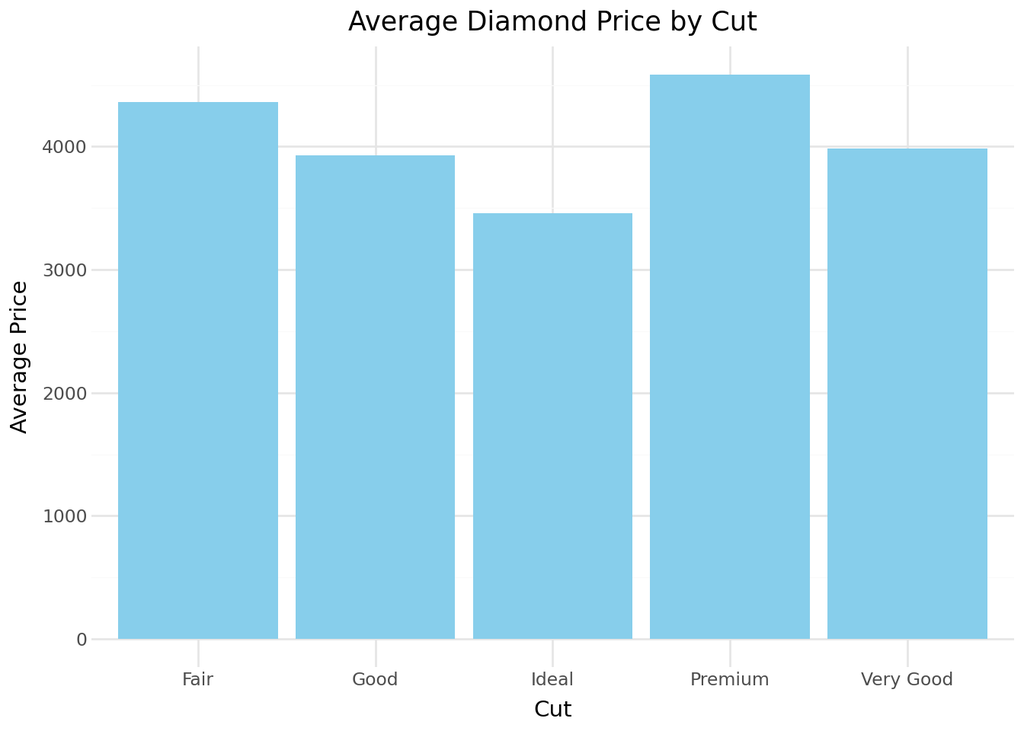

```python
(
    ggplot(diamonds.to_pandas()) +
    aes(x='cut', y='price') +
    geom_bar(stat='summary', fill='skyblue') +
    labs(title='Average Diamond Price by Cut', x='Cut', y='Average Price') +
    theme_minimal()
)
```

The bar chart reveals which cut types are generally more expensive, helping detect a pattern between cut and price.

**Compute correlation using polars**

```python
# Select numeric columns
numeric_cols = ["carat", "depth", "table", "price", "x", "y", "z"]

# Compute correlation matrix
corr_matrix = diamonds.select(numeric_cols).to_pandas().corr()
corr_matrix
```

|  | carat | depth | table | price | x | y | z |
| --- | --- | --- | --- | --- | --- | --- | --- |
| carat | 1.000000 | 0.028224 | 0.181618 | 0.921591 | 0.975094 | 0.951722 | 0.953387 |
| depth | 0.028224 | 1.000000 | -0.295779 | -0.010647 | -0.025289 | -0.029341 | 0.094924 |
| table | 0.181618 | -0.295779 | 1.000000 | 0.127134 | 0.195344 | 0.183760 | 0.150929 |
| price | 0.921591 | -0.010647 | 0.127134 | 1.000000 | 0.884435 | 0.865421 | 0.861249 |
| x | 0.975094 | -0.025289 | 0.195344 | 0.884435 | 1.000000 | 0.974701 | 0.970772 |
| y | 0.951722 | -0.029341 | 0.183760 | 0.865421 | 0.974701 | 1.000000 | 0.952006 |
| z | 0.953387 | 0.094924 | 0.150929 | 0.861249 | 0.970772 | 0.952006 | 1.000000 |

A correlation closer to 1 or -1 indicates a strong linear relationship. For example, carat and price are usually positively correlated, larger diamonds tend to cost more.

**Visualizing Correlation: Scatter Plot**

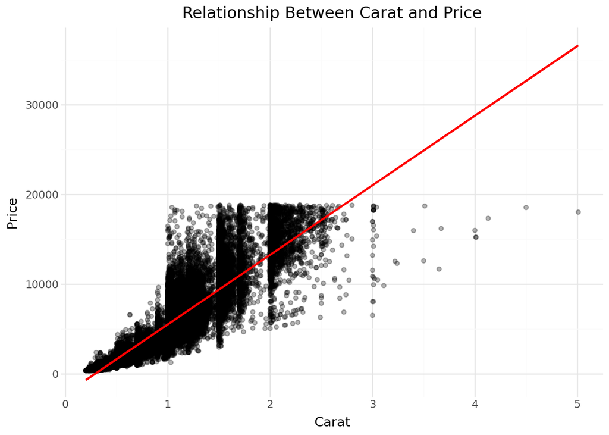

```python
(
    ggplot(diamonds.to_pandas()) +
    aes(x='carat', y='price') +
    geom_point(alpha=0.3) +
    geom_smooth(method='lm', color='red') +
    labs(title='Relationship Between Carat and Price', x='Carat', y='Price') +
    theme_minimal()
)
```

The scatter plot with a fitter line shows a positive linear relation: as carat increases, price also increases.

**Another Relationship: Depth vs. Price**

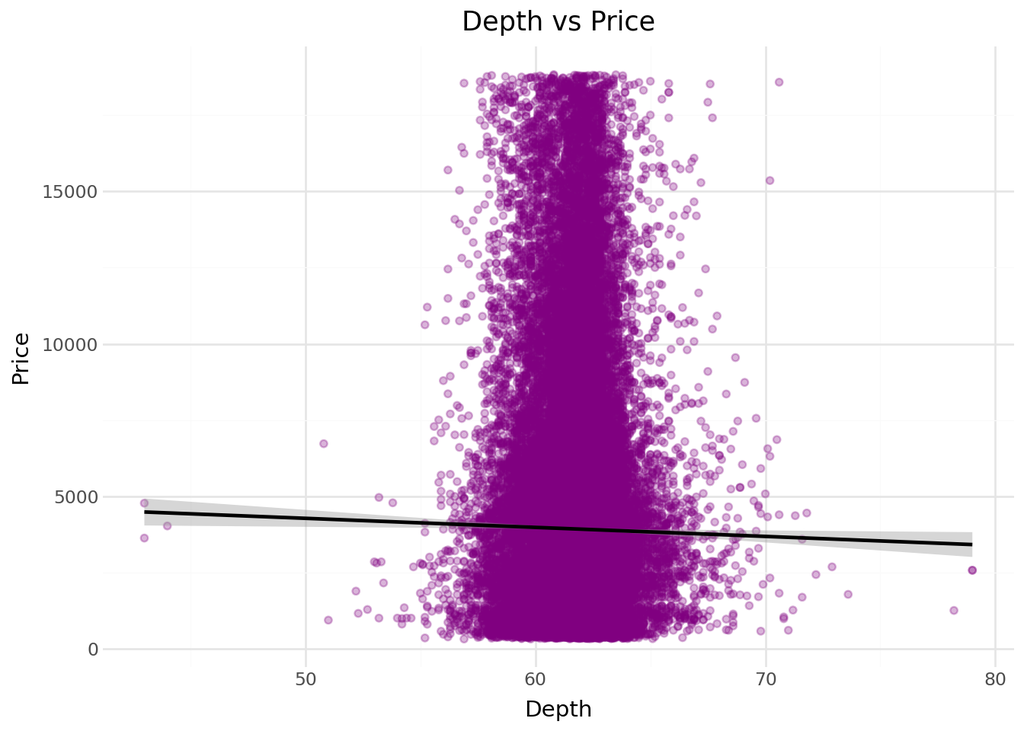

```python
(
    ggplot(diamonds.to_pandas()) +
    aes(x='depth', y='price') +
    geom_point(alpha=0.3, color='purple') +
    geom_smooth(method='lm', color='black') +
    labs(title='Depth vs Price', x='Depth', y='Price') +
    theme_minimal()
)
```

If the line is relatively flat, it indicates a weak or no correlation between depth and price.

## 5. Lab Activity

**Activity 1: Patter Detection**

Using the same dataset, find which color of diamond has the highest average price.

- Use polars for summarization.
- Visualize using plotnine.

**Activity 2: Correlation Analysis**

Compute correlations of all numeric variables and identify:

1. Which variable has the strongest positive correlation with price?
2. Which has the weakest correlation?

**Activity 3: Visualization Challenge**

Plot a scatter plot showing the relationship between x (length) and price.

- Add a smooth line.
- Interpret the result.

**Activity 4: Kaggle Challenge**

Choose a dataset from Kaggle and:

1. Identify at least two patterns in the data.
2. Perform correlation analysis on at least three numeric variables.
3. Create two visualizations using plotnine.
4. Write a short interpretation (3 - 5 sentences).

*“When the lessons feel hard, remember: diamonds are made under pressure.”*

- The Data Samurai

[figure not shown]